# Please scroll down for the report

Most code is bundled in the section, for cleaner text later on.

```python
import numpy as np
import igraph as ig
import graph_qa as qa
import matplotlib.pyplot as plt
import cPickle as pickle
%matplotlib inline
from IPython.display import SVG
```

```python
graph = ig.Graph.Read_GraphML('drugbank-ext-v3.grahpml')
```

```python
def plot_graph(g, highlight):
    for v in g.vs:
        if v['orig_id'] in [w['orig_id'] for w in highlight]:
            v['size'] = 6
            v['color'] = 'blue'
        else:
            v['size'] = 2

    plotstyle2 = {
        'vertex_label': g.vs['name'],
        'vertex_label_size': 8,
        'vertex_label_dist': 3,
        'bbox': (500,500),
        'edge_width': .02,
        'vertex_frame_width': 0
    }
    return ig.plot(g, **plotstyle2)

def get_neighborhood_graph(vertices,order=1,graph=graph):
    neighborhood = graph.neighborhood(vertices,order=order)
    neighborhood = [i for x in neighborhood for i in x ]
    return graph.induced_subgraph(neighborhood)


# Shortcuts
amiodarone  = graph.vs.find(uri = qa.find_drugbank_entity('amiodarone'))
lidocaine   = graph.vs.find(uri = qa.find_drugbank_entity('lidocaine'))
adenosine   = graph.vs.find(uri = qa.find_drugbank_entity('adenosine'))
propranolol = graph.vs.find(uri = qa.find_drugbank_entity('propranolol'))
hospira = graph.vs[24083]
cytochrome = graph.vs[8451]

amiodarone['name']  = 'amiodarone'
lidocaine['name']   = 'lidocaine'
adenosine['name']   = 'adenosine'
propranolol['name'] = 'propranolol'
hospira['name']     = 'Hospira inc'
cytochrome['name']  = 'Cytochrome'

simple_plot = {
    'vertex_label': simple_subgraph.vs['name'],
    'vertex_label_size': 8,
    'vertex_label_dist': 2,
    'bbox': (300,300),
    'vertex_size': 10,
    'edge_width': .2
}

highlight = [amiodarone,lidocaine,adenosine,propranolol]

# Simple subgraph
simple_subgraph = graph.induced_subgraph(highlight+[hospira,cytochrome])

# Neighborhood graph
nb_graph = get_neighborhood_graph([adenosine,amiodarone,lidocaine,propranolol])

small_nb_graph = nb_graph.induced_subgraph(range(len(nb_graph.vs)))
hub1 = small_nb_graph.vs.find(uri = '<http://bio2rdf.org/drugbank_vocabulary:Resource>')
hub2 = small_nb_graph.vs.find(uri = '<http://bio2rdf.org/drugbank_resource:bio2rdf.dataset.drugbank.R3>')
small_nb_graph.delete_vertices([hub1.index,hub2.index])

# degrees = [[v.index, v.degree()] for v in nb_graph.vs]
# degrees = sorted(degrees, key=lambda x: x[1])
```

```python
def load_experiment(filename):
    experiment = pickle.load(open(filename,'rb'))

    ns=[]
    scores=[]
    values=[]
    for res in experiment['results']:
        ns.append(res['output'][0])
        vals = res['output'][1]
        if max(vals)-min(vals) == 0:
            scores.append([0, 0, 0, 0])
        else:
            scores.append( 1 - (vals - min(vals)) / (max(vals) - min(vals)))
        values.append(vals)

    scores = np.array(scores)
    values = np.array(values)
    return ns, values, scores, experiment

def plot_results(experiment, values, x_trials=False):
    colors = [(0.867, 0.753, 0.082), (0.792, 0.075, 0.184), (0.337, 0.588, 0.788), (0.467, 0.714, 0.243)]
    plt.figure(figsize=(15,5))

    if x_trials:
        x_val = np.linspace(0, 1, len(experiment['trials']))
        plt.xticks(x_val, experiment['trials'])
    else:
        x_val = experiment['trials']
        plt.locator_params(nbins=20,axis='x')

    for i in range(4):
        if i == experiment['correct']:
            plt.plot(x_val, values[:,i],
                     linewidth=3, color='black',label='Ans '+'abcd'[i])
        else:
            plt.plot(x_val, values[:,i],
                     linewidth=1.5, color=colors[i],label='Ans '+'abcd'[i])

    plt.title(experiment['expid']+':   '+experiment['comments'], y =-.2)
    plt.legend(loc='upper center', bbox_to_anchor=(0.5, 1.075),
                ncol=4, fancybox=True)

    ax = plt.axes()
    ax.set_frame_on(False)
    ax.tick_params(axis='y',width=0)
    ax.get_xaxis().tick_bottom()
    ax.get_yaxis().tick_left()

    xmin, xmax = ax.get_xaxis().get_view_interval()
    ymin, ymax = ax.get_yaxis().get_view_interval()
    ax.add_artist(plt.Line2D((xmin, xmin), (ymin, ymax), color='black', linewidth=1))

    ax.grid(axis='y', which='major', linestyle='-',alpha=.4)
    ax.grid(axis='y', which='minor', linestyle='-',alpha=.2)
    ax.minorticks_on()
    ax.locator_params(nbins=20, axis='y')

    plt.ylim((ymin-.01,ymax+.1))
    plt.show()

def med_med_qa_distance(distances):
	return np.median(np.median(distances,axis=0))

def avg_avg_qa_distance(distances):
	return np.average(np.average(distances,axis=0))
```

# Outline

- DrugBank Graph
- Setup
  - Question Collection
  - Representing the questions in DrugBank
  - The Q-A distance
  - Measurements
- Results

# DrugBank Graph

DrugBank was exported to a connectivity list, which was then imported in [iGraph](http://igraph.org/) for Python, a network analysis package. We thus obtained a graph with 391089 edges and 1603540 edges (that can also be accessed in GraphML format). Every vertex corresponds to a DrugBank entity (via its 'uri' attribute) and every edge corresponds to any relation. Edges in the graph are assigned several weights: - rel_weight: the number of relations between two entities - deg_weight: the degree-corrected weight (Moore et al., 2011). The edge $(u,v)$ has weight $w(u,v) = \log(\deg(u)) + \log(\deg(v))$. - inv_rel_weight: the inverse of the rel_weight such that nodes with many edges in between are 'close'.

*(Question: why use inv*rel_weight and not max(rel_weight) - rel_weight?)_

We briefly explore the graph. For example, let's look at the four drugs from Question 3 (see later): 'amiodarone', 'lidocaine', 'adenosine' and 'propranolol'. The shortest path from Amiodarone to all other drugs leads via two nodes: the DrugBank resource "Hospira Inc" and an enzyme called "Cytochrome P450 2D6". Save that for readability and plot the subgraph induced by these vertices

```python
ig.plot(simple_subgraph, **simple_plot)
```

[figure not shown]

What does the surrounding network look like? To get an idea, we look at the graph induced by the set of successors of the four drugs

```python
plot = plot_large_graph(subgraph,highlight)
SVG(plot._repr_svg_())
```

[figure not shown]

The two nodes at the center are interesting here. We can look them up and see that they correspond to - `<http://bio2rdf.org/drugbank_vocabulary:Resource>`  
- `<http://bio2rdf.org/drugbank_resource:bio2rdf.dataset.drugbank.R3>`,

both highly connected nodes. To give an impression: they have 251568 and 316515 successors respectively, which amounts to 64% and 80% of the network. As a result, the subgraph of all vertices that are two steps from one of the drugs (the *neighbourhoodgraph of order 2*, if you like) contains 81% of the original graph. What happens when we remove these?

```python
plot = plot_large_graph(small_nb_graph,highlight)
SVG(plot._repr_svg_())
```

[figure not shown]

If we now take all successors of the points in this subgraph, then the subgraph induced by these points covers less then 0.01% of the original graph (instead of 81%)! Of course, this is no surprise. It only indicates that highly connected neighbours can be a problem: they reduce the step distance between any two given nodes (and it will be likely to be 2). Ranking multiple choice answers based on their distance to the question cluster, might thus be unlikely to succeed based on the step distance only.

In fact, we can indentify the most highly connected nodes in the entire network by looking at the degree distribution (both axis are logarithmic). Then we see that there are only three nodes that reach more than 10% of the network. Two we have seen already, the third one reaches 37% of the network.

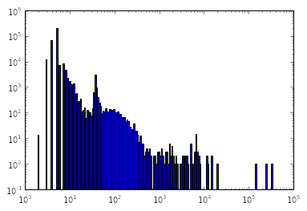

```python
plt.hist(graph.degree(), bins=np.logspace(.1,6,200), log=True);
plt.gca().set_xscale("log")
plt.show()
```

# Setup

## Question Collection

The question collection was filtered in several ways. Firstly, we only gathered multiple choice question sets with one correct answer and more than two options (two options often boiled down to a 'binary' true/false). This left us with 1360 questions with 3-5 options each. We then removed all questions where multiple answers where 'implicitely' true, so to speak. That is, questions of the form: > [Question] > 1. Some answer > 2. Some other answer > 3. Both 1. and 2. > 4. None of the above.

After these restrictions, 654 questions remained with perhaps relatively little text: an average of 10.8 words in each question (sd 8.9) and an average of 3.9 words in each answer option (sd 2.9). Using a crude index, we ranked questions on text content and selected six high-ranked questions for which the four mc options all consisted of a drug (see below). This choice is completely motivated by our dataset (Drugbank). Using questions asking for some drugs at least excludes the possibility of 'misrepresenting' the possible answers in DrugBank. Of course, representing the question remains a challenge, of which we will come to speak later. Below you find a list of the six questions used. The highlighted words were used in representing the question, but we return to this point later

By the way: 'question' always refers to the *question text* and the 'answers' the the multiple choice options.

> **Question 1** (Q83#4)

> A patient with Type I **diabetes** presents with significant **water retention** and **pulmonary congestion**. **Serum creatinine**, **BUN** and **potassium** were significantly elevated. The diagnosis was advanced **renal failure**. A diuretic was given to treat **water retention**, but shortly thereafter the patient exhibited **cardiac conduction** changes which progressed to **heart block** and **cardiac arrest**. The diuretic which was determined to cause this event was probably: 0. furosemide (Lasix) 1. triamterene (Dyrenium) **(Correct)** 2. chlorothiazide (Diuril) 3. bumetanide (Bumex)

> **Question 2** (Q119#2)

> Synthetic analog of **deoxyadenosine**; **active triphosphate** form inhibits **viral replication** by competitively inhibiting **HIV reverse transcriptase** and by **chain termination** ;may be prescribed concurrently with **zidovudine** or given as **monotherapy**; major clinical toxicity is a **dose-dependent pancreatitis**. 1. zalcitabine (Hivid, ddc) 2. trifluridine (Viroptic) 3. didanosine (Videx, ddI) **(Correct)** 4. foscarnet (Foscavir)

> **Question 3** (Q34#18)

> A patient is being treated with **digoxin** for **congestive heart failure**. To enhance **inotropic effects**, the dosage was increased. Soon afterwards, the patient complained of **dizziness**, **fatigue**, and disturbances in **color vision**. An **ECG** was taken and exhibit **arrhythmias** consistent with **digitialis intoxication**. What **antiarrhythmic** drugs might be used to treat worsening **ventricular arrhythmias** with **hemodynamic compromise**? 1. amiodarone (Cordarone) 2. lidocaine (Xylocaine) **(Correct)** 3. adenosine (Adenocard) 4. propranolol (Inderal)

> **Question 4** (Q16#34)

> A patient is admitted for treatment of **myocardial infarction**. During a prolonged recovery period, the patient experienced episodes of **ventricular tachycardia**. Following discharge from hospital, the patient was instructed to take a drug to prevent recurrence of ventricular tachycardia. After a few days, the patient complained of **dizziness** and then lost **consciousness**. Upon admission to the hospital, the patient was found to be somewhat **hypokalemic**. A diagnosis of **Torsades de Pointes** was made. A test to determine the blood level of the **antiarrhythmic** reveal the drug was present in a slightly subtherapeutic level. What was the drug? 1. sotalol (Betapace) 2. procainamide (Procan SR, Pronestyl-SR) 3. quinidine gluconate (Quinaglute, Quinalan) **(Correct)** 4. lidocaine (Xylocaine)

> **Question 5** (Q26#11)

> An elderly male patient has **essential hypertension**, **congestive heart failure**, and **type I insulin-dependent diabetes**. His congestive failure developed secondary to **coronary vascular disease** associated with **hyperlipidemia**. What **antihypertensive drug**(s) may be most appropriate for this patient?  
> 1. chlorothiazide (Diuril) 2. captopril (Capoten) **(Correct)** 3. propranolol (Inderal) 4. metoprolol (Lopressor)

> **Question 6** (Q121#5)

> Mainly eliminated by **renal mechanisms** as the **hypoxanthine metabolite**, this **antiviral agent** is effective for treating acute **keratoconjunctivitis** (**ointment**) and **HSV encephalitis** (i.v.) 1. vidarabine (Vira-A) **(Correct)** 2. ganciclovir (DHPG, Cytovene) 3. foscarnet (Foscavir) 4. zidovudine (Retrovir, AZT, azidothymidine)

## Representing the questions in the Drugbank Graph

We aim to rank the answers based on their distance to the question. So we first have to represent the question and the answers in the graph. As mentioned earlier, all of the multiple choice answers can (except for question 4) unambiguously be represented in Drugbank. The questions, however, rarely contain drugbank entities. But using a full-text search, many of the terms in the question, can be found in literals in drugbank. So we adopted this approach and performed a full-text search on drugbank for each of the boldfaced queries in the question text. We used Virtuoso's (sort of) built-in precision search and did *not* further rank the search results. Consequently, the very first search result will generally not be a good representation of the term. Instead, we used the first $n$ results for each query to represent the question and analyzed the influence of the size of $n$.

Again, this is a very crude approach with many problems. For example, some queries might yield many results and could be 'overrepresented' when increasing $n$, while other possibly more relevant nodes could be 'underrepresented'.

## Measuring the Q-A distance

**Note.** Instead of taking first the median, then the average, we could also take averages or medians only --- This perhaps deserves more thought. A comparison for one question suggests that median-median seperates the answers better.

The length of the shortest path depends on the edge_weight used. That is: either deg_weight, rel_weight, inv_rel_weight or no weight for the step distance.

## Scoring performance

# Results

We performed several subexperiments with several goals. 1. The first goal was simply to implement everything, to 'play' with the graph, to see what happens what choices you have to make etc. 2. More specifically, the second and main goal was to find out the influence of the representation of the question on the ranking, i.e. the influence of $n$ (the number of full-text search results per query included). 3. The third goal was to compare performance for different weights used. 4. The fourth goal was to briefly check if the choice of the Q-A distance had a lot of impact.

## Subexperiment 1

**Note.** Acually called 'Experiment 3' in all other files

We start with the second. For all six questions, we calculated the QA distance using in the representation of the question at most $n=5,10,15,20,25,50,75,100,200,400,700, 1000$ and $1500$ entities per full text search query. For all questions, all search results were exhausted at $n=1500$. At this point the top-ranking anwers for Question 1, Question 2 and Question 6 were indeed the correct answers:

| Question | Score at $n=1500$ |
| --- | --- |
| Q1 | **1,00** |
| Q2 | **1,00** |
| Q3 | 0,20 |
| Q4 | 0,00 |
| Q5 | 0,52 |
| Q6 | **1,00** |

For Question 1 we also did the measurements for n in steps of 10 from 0 to 500. The distances and scores are shown in the next two graphs. The thick black line represents the correct answer (the lower compared to the others, the better). Observe the fluctuations due to different representations.

[figure not shown]

[figure not shown]

```python
ns,vals,scores,exp = load_experiment('Experiment 3/qa-experiment3-q1c.p')
exp['comments'] ='Score for each answer to Question 1, for different values of n'
plot_results(exp, vals)
exp['comments'] ='Distance from each answer to Question 1 to question, for different values of n'
plot_results(exp, scores)
```

## More Results

For the other questions, graphs of the distances and scores are displayed twice, to allow for easier comparison. Please note that the ticks on the x-axis are not equally spaced!

```
============================== QUESTION 1 =================================
```

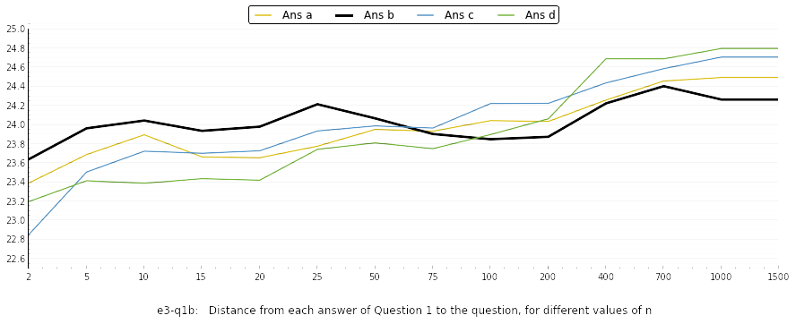

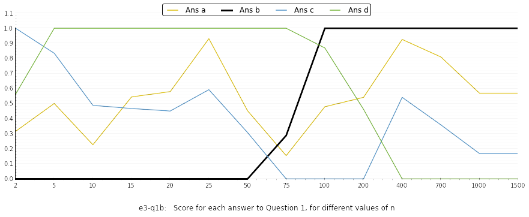

```
============================== QUESTION 2 =================================
```

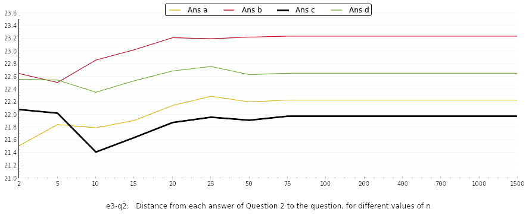

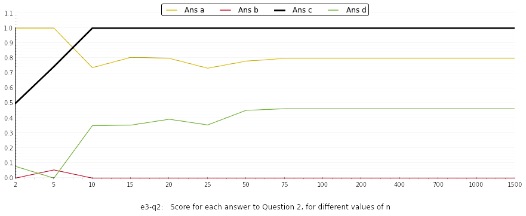

```
============================== QUESTION 3 =================================
```

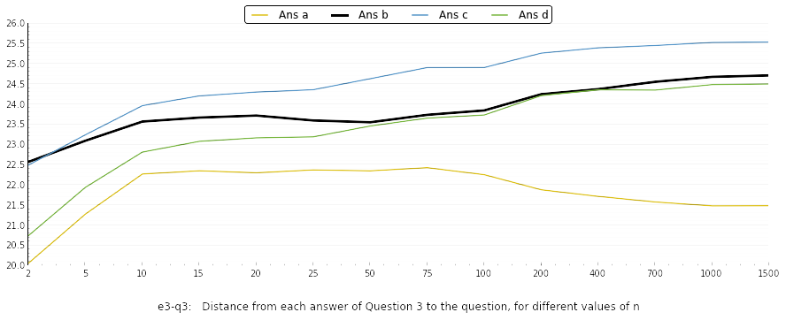

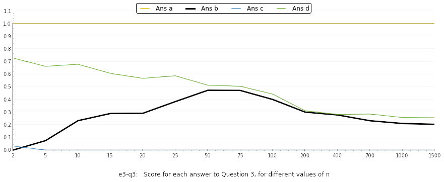

```
============================== QUESTION 4 =================================
```

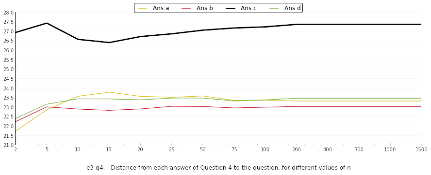

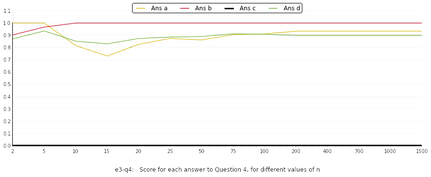

```
============================== QUESTION 5 =================================
```

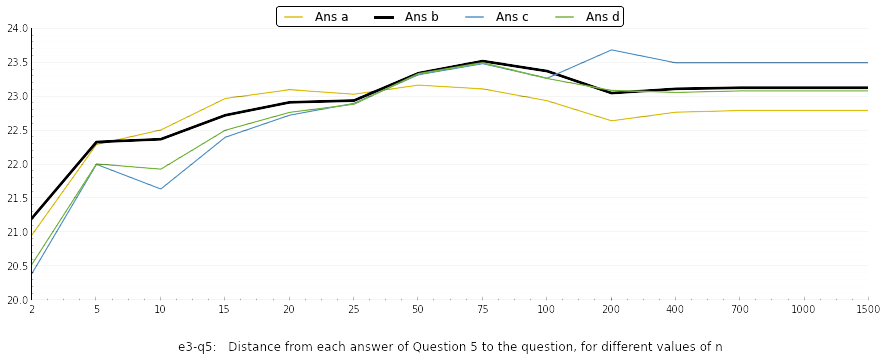

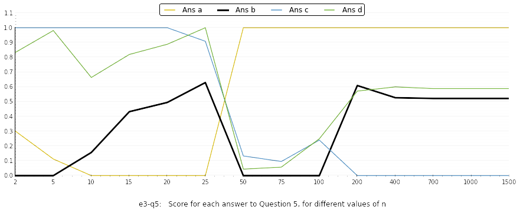

```
============================== QUESTION 6 =================================
```

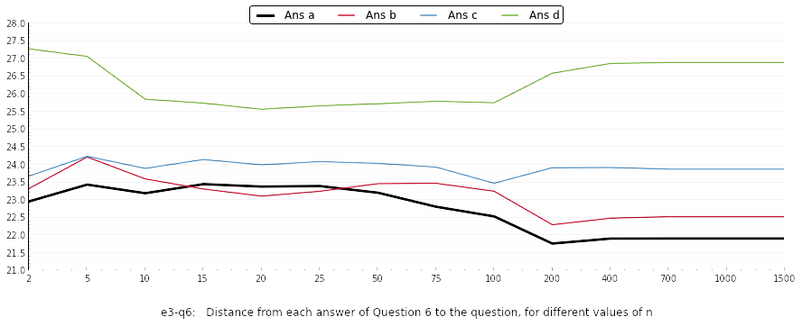

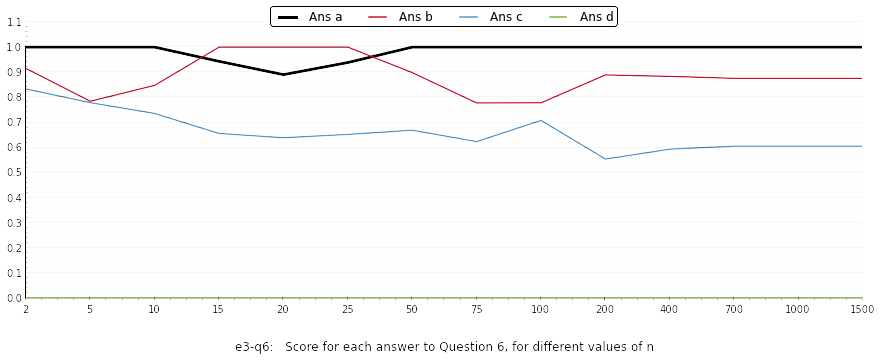

```python
for expid in ['q1b','q2','q3','q4','q5','q6']: ns,vals,scores,exp = load_experiment('Experiment 3/qa-experiment3-'+expid+'.p');print '\n============================== QUESTION ' +expid[1] +' =================================\n';exp['comments'] ='Distance from each answer of Question '+expid[1]+' to the question, for different values of n';plot_results(exp, vals, True);exp['comments'] ='Score for each answer to Question '+expid[1]+', for different values of n';plot_results(exp, scores, True)
```

```
============================== QUESTION 1 =================================
```

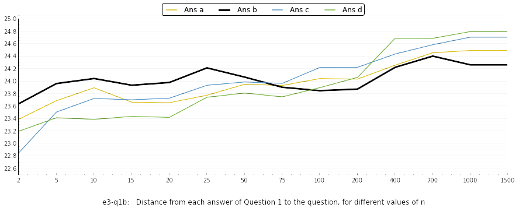

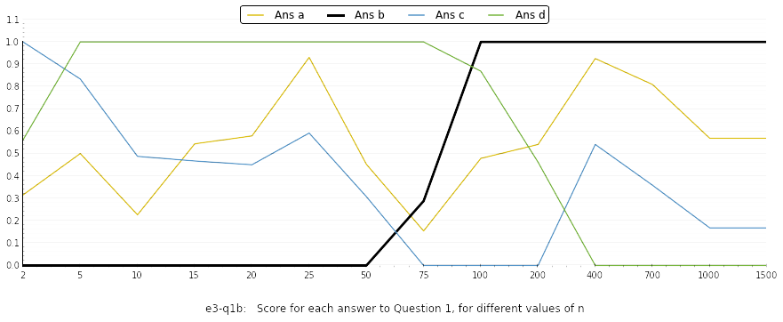

```
============================== QUESTION 2 =================================
```

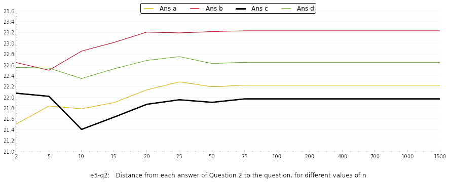

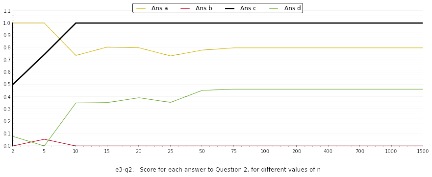

```
============================== QUESTION 3 =================================
```

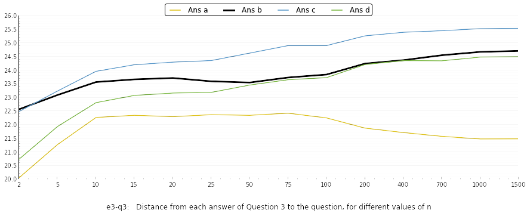

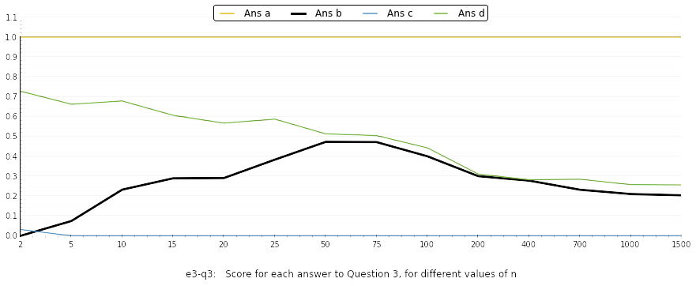

```
============================== QUESTION 4 =================================
```

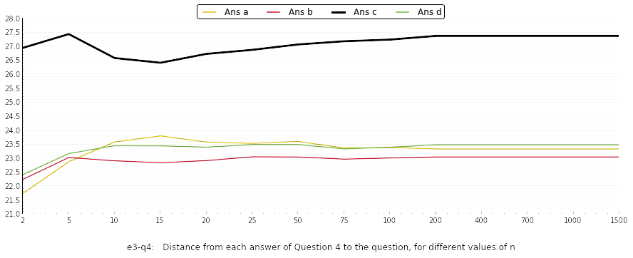

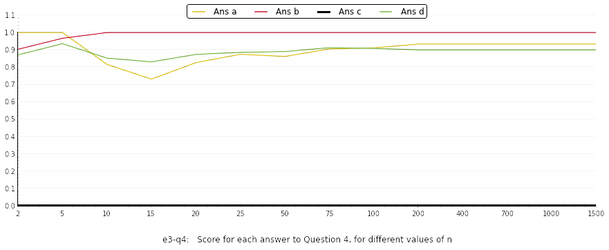

```
============================== QUESTION 5 =================================
```

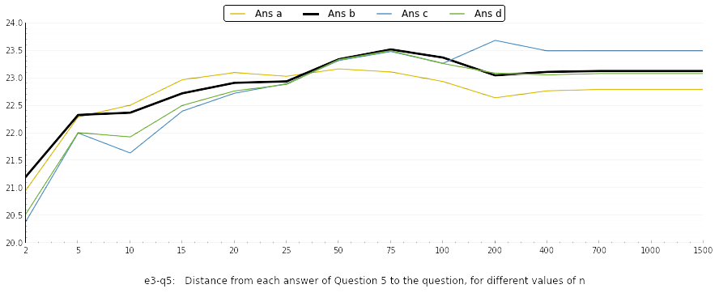

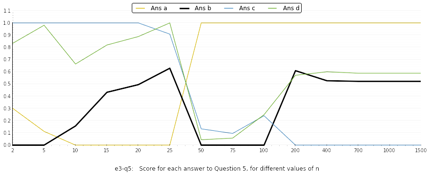

```
============================== QUESTION 6 =================================
```

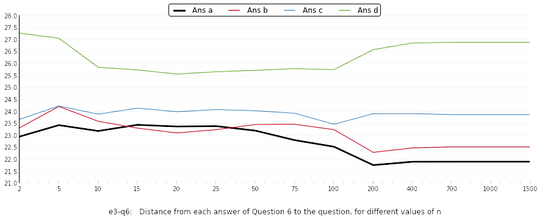

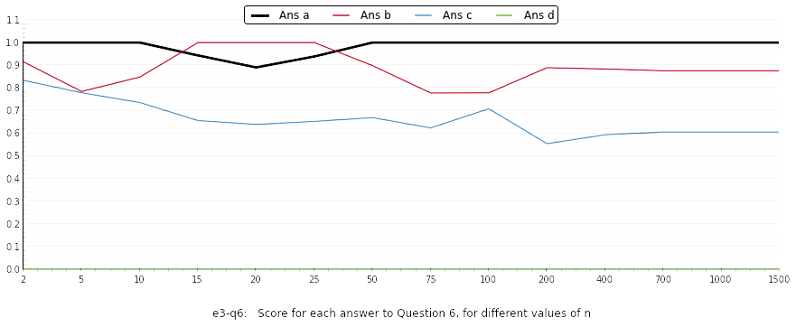

```python
for expid in ['q1b','q2','q3','q4','q5','q6']: ns,vals,scores,exp = load_experiment('Experiment 3/qa-experiment3-'+expid+'.p');print '\n============================== QUESTION ' +expid[1] +' =================================\n';exp['comments'] ='Distance from each answer of Question '+expid[1]+' to the question, for different values of n';plot_results(exp, vals, True);exp['comments'] ='Score for each answer to Question '+expid[1]+', for different values of n';plot_results(exp, scores, True)
```

### Influence of representation

These results suggest a way to improve the ranking procedure: look for the 'optimal' representation of the question and the answers.  
For example, take Question 5:

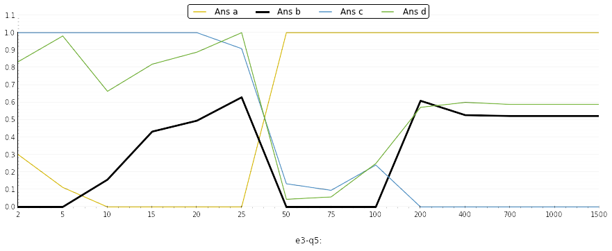

```python
ns,vals,scores,exp = load_experiment('Experiment 3/qa-experiment3-q5.p'); exp['comments'] = ''; plot_results(exp, scores, True)
```

When representing the question text by the first 50 to 100 search results, the distance between answer b, c, and d decreased. Apparently, the entities added made it more difficult to distinguish these three and where moreover 'closer' to answer a. That would clearly not be the best representation. Perhaps there is a way to improve this.

As another example of the effect of representation, take Question 4. The correct answer ('quinidine gluconate') has an ambiguous representation in DrugBank and therefore we performed the experiment using only 'quinedine gluconate'; using both 'quinedine' and 'quinedine gluconate'; and using only 'quinedine'.

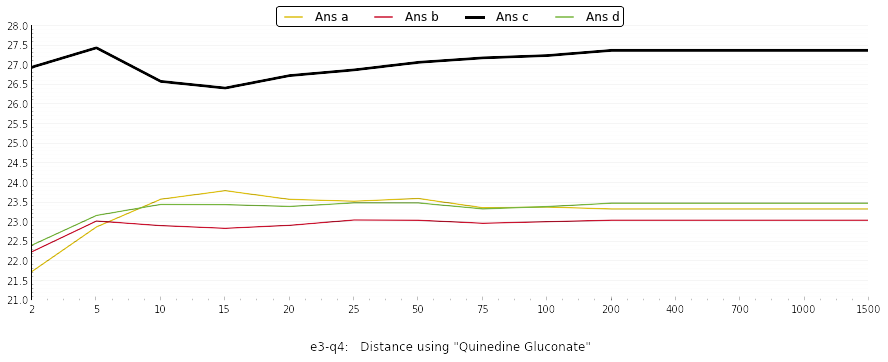

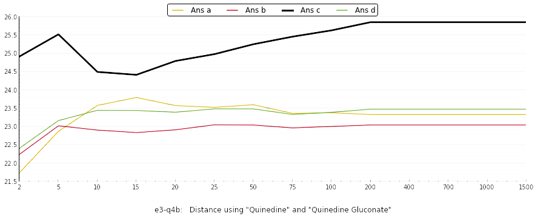

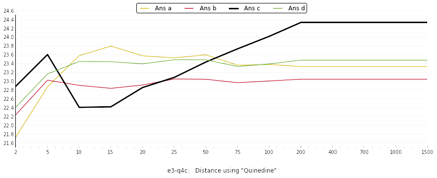

```python
ns,vals,scores,exp = load_experiment('Experiment 3/qa-experiment3-q4.p'); exp['comments'] = 'Distance using "Quinedine Gluconate"'; plot_results(exp, vals, True)
ns,vals,scores,exp = load_experiment('Experiment 3/qa-experiment3-q4b.p'); exp['comments'] = 'Distance using "Quinedine" and "Quinedine Gluconate"'; plot_results(exp, vals, True)
ns,vals,scores,exp = load_experiment('Experiment 3/qa-experiment3-q4c.p'); exp['comments'] = 'Distance using "Quinedine"'; plot_results(exp, vals, True)
```